# Lecture 5: Preprocessing and sklearn pipelines

Andrew Roth (Slides adapted from Varada Kolhatkar and Firas Moosvi)

## Announcements

- HW1 grades have been posted.
  - See syllabus about regrade request etiquette.
- Homework 1 solutions have been posted on Canvas under Files tab. Please do not share them with anyone or do not post them anywhere.
- Syllabus quiz is due Jan 24.
- HW3 should be available.

## Learning outcomes

From this lecture, you will be able to

- Explain motivation for preprocessing in supervised machine learning;
- Discuss golden rule in the context of feature transformations;
- Identify when to implement feature transformations such as imputation, scaling, and one-hot encoding in a machine learning model development pipeline;
- Use `sklearn` transformers for applying feature transformations on your dataset;
- Use `sklearn.pipeline.Pipeline` and `sklearn.pipeline.make_pipeline` to build a preliminary machine learning pipeline.

## Recap

- Decision trees: Split data into subsets based on feature values to create decision rules
- $k$-NNs: Classify based on the majority vote from k nearest neighbors
- SVM RBFs: Create a boundary using an RBF kernel to separate classes

## Motivation

- So far we have seen
  - Three ML models (decision trees, $k$-NNs, SVMs with RBF kernel)
  - ML fundamentals (train-validation-test split, cross-validation, the fundamental tradeoff, the golden rule)
- Are we ready to do machine learning on real-world datasets?
  - Very often real-world datasets need preprocessing before we use them to build ML models.

## (iClicker) Exercise 5.1

iClicker cloud join link: **https://join.iclicker.com/HTRZ**

Take a guess: In your machine learning project, how much time will you typically spend on data preparation and transformation?

- 1. ~80% of the project time
- 2. ~20% of the project time
- 3. ~50% of the project time
- 4. None. Most of the time will be spent on model building

The question is adapted from [here](https://developers.google.com/machine-learning/crash-course/numerical-data).

## Preprocessing motivation: example

You’re trying to find a suitable date based on:

- Age (closer to yours is better).
- Number of Facebook Friends (how should we interpret?).

## Preprocessing motivation: example

- You are 30 years old and have 250 Facebook friends.

| Person | Age | #FB Friends | Euclidean Distance Calculation | Distance |
| --- | --- | --- | --- | --- |
| A | 25 | 400 | √(5² + 150²) | 150.08 |
| B | 27 | 300 | √(3² + 50²) | 50.09 |
| C | 30 | 500 | √(0² + 250²) | 250.00 |
| D | 60 | 250 | √(30² + 0²) | 30.00 |

Based on the distances, the two nearest neighbors (2-NN) are:

- **Person D** (Distance: 30.00)
- **Person B** (Distance: 50.09)

What’s the problem here?

# Common transformations

## Imputation: Fill the gaps! (🟩 🟧 🟦)

Fill in missing data using a chosen strategy:

- **Mean**: Replace missing values with the average of the available data.
- **Median**: Use the middle value.
- **Most Frequent**: Use the most common value (mode).
- **KNN Imputation**: Fill based on similar neighbors.

### Example:

Imputation is like filling in your average or median or most frequent grade for an assessment you missed.

```python
from sklearn.impute import SimpleImputer
imputer = SimpleImputer(strategy='mean')
X_imputed = imputer.fit_transform(X)
```

## Scaling: Everything to the same range! (📉 📈)

Ensure all features have a comparable range.

- **StandardScaler**: Mean = 0, Standard Deviation = 1.

### Example:

Scaling is like adjusting the number of everyone’s Facebook friends so that both the number of friends and their age are on a comparable scale. This way, one feature doesn’t dominate the other when making comparisons.

```python
from sklearn.preprocessing import StandardScaler
scaler = StandardScaler()
X_scaled = scaler.fit_transform(X)
```

## (iClicker) Exercise 5.2

iClicker cloud join link: **https://join.iclicker.com/HTRZ**

Select all of the following statements which are TRUE.

- 1. `StandardScaler` ensures a fixed range (i.e., minimum and maximum values) for the features.
- 2. `StandardScaler` calculates mean and standard deviation for each feature separately.
- 3. In general, it’s a good idea to apply scaling on numeric features before training $k$-NN or SVM RBF models.
- 4. The transformed feature values might be hard to interpret for humans.
- 5. After applying `SimpleImputer` the transformed data has a different shape than the original data.

## One-Hot encoding: 🍎 → 1️⃣ 0️⃣ 0️⃣

Convert categorical features into binary columns.

- Creates new binary columns for each category.
- Useful for handling categorical data in machine learning models.

### Example:

Turn “Apple, Banana, Orange” into binary columns:

| Fruit | 🍎 | 🍌 | 🍊 |
| --- | --- | --- | --- |
| Apple 🍎 | 1 | 0 | 0 |
| Banana 🍌 | 0 | 1 | 0 |
| Orange 🍊 | 0 | 0 | 1 |

```python
from sklearn.preprocessing import OneHotEncoder
encoder = OneHotEncoder()
X_encoded = encoder.fit_transform(X)
```

## Ordinal encoding: Ranking matters! (⭐️⭐️⭐️ → 3️⃣)

Convert categories into integer values that have a meaningful order.

- Assign integers based on order or rank.
- Useful when there is an inherent ranking in the data.

### Example:

Turn “Poor, Average, Good” into 1, 2, 3:

| Rating | Ordinal |
| --- | --- |
| Poor | 1 |
| Average | 2 |
| Good | 3 |

```python
from sklearn.preprocessing import OrdinalEncoder
encoder = OrdinalEncoder()
X_ordinal = encoder.fit_transform(X)
```

# `sklearn` Transformers vs Estimators

## Transformers

- Are used to transform or preprocess data.
- Implement the `fit` and `transform` methods.
  - `fit(X)`: Learns parameters from the data.
  - `transform(X)`: Applies the learned transformation to the data.
- **Examples**:
  - **Imputation** (`SimpleImputer`): Fills missing values.
  - **Scaling** (`StandardScaler`): Standardizes features.

> `fit_transform(X)`: Convenience method for calling `fit` and then `transform` on the same data.

## Estimators

- Used to make predictions.
- Implement `fit` and `predict` methods.
  - `fit(X, y)`: Learns from labeled data.
  - `predict(X)`: Makes predictions on new data.
- Examples: `DecisionTreeClassifier`, `SVC`, `KNeighborsClassifier`

> Regression models are also estimators

# Feature transformations and the golden rule

## How to carry out cross-validation? (improper)

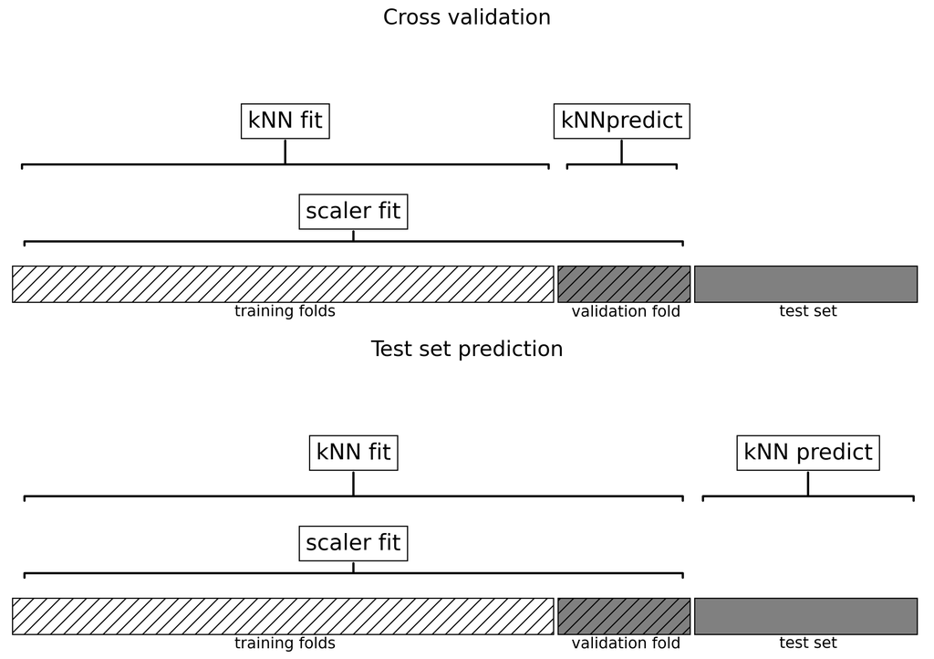

## How to carry out cross-validation? (proper)

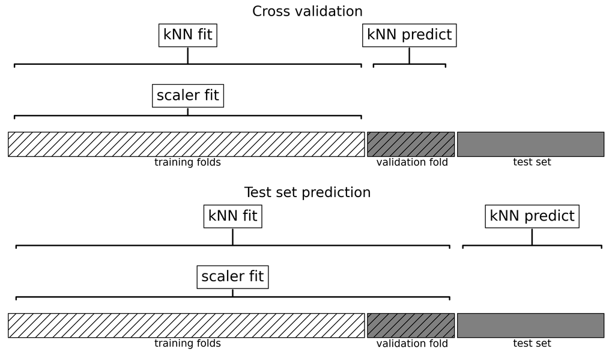

## The golden rule in feature transformations

- **Never** transform the entire dataset at once!
- **Why**? It leads to **data leakage** — using information from the test set in your training process, which can artificially inflate model performance.
- **Fit** transformers like scalers and imputers on the **training set only**.
- **Apply** the transformations to both the training and test sets **separately**.

### Example:

```python
from sklearn.preprocessing import StandardScaler
scaler = StandardScaler()
X_train_scaled = scaler.fit_transform(X_train)
X_test_scaled = scaler.transform(X_test)
```

## `sklearn` Pipelines

- Pipeline is a way to chain multiple steps (e.g., preprocessing + model fitting) into a single workflow.
- Simplify the code and improves readability.
- Reduce the risk of data leakage by ensuring proper transformation of the training and test sets.
- Automatically apply transformations in sequence.

### Example:

Chaining a `StandardScaler` with a `KNeighborsClassifier` model.

```python
from sklearn.pipeline import make_pipeline
from sklearn.preprocessing import StandardScaler
from sklearn.neighbors import KNeighborsClassifier

pipeline = make_pipeline(StandardScaler(), KNeighborsClassifier())

pipeline.fit(X_train, y_train)
y_pred = pipeline.predict(X_test)
```

## (iClicker) Exercise 5.3

iClicker cloud join link: **https://join.iclicker.com/HTRZ**

Select all of the following statements which are TRUE.

- 1. You can have scaling of numeric features, one-hot encoding of categorical features, and scikit-learn estimator within a single pipeline.
- 2. Once you have a `scikit-learn` pipeline object with an estimator as the last step, you can call `fit`, `predict`, and `score` on it.
- 3. You can carry out data splitting within `scikit-learn` pipeline.
- 4. We have to be careful of the order we put each transformation and model in a pipeline.

[figure not shown]